# Ejercicio Macrothele calpeiana

```r
library(tidyverse)
library(modEvA)
library(fuzzySim)
library(foreign)
```

```r
datos <- read_csv("datos.csv", show_col_types = FALSE) %>%
  na.omit()
head(datos)
```

| fid | CuadrID | latitude | longitude | Area_hec | HIE_FAS | SAL_SAL | ALY_DIC | DIS_JEA | VIP_LAT | CAP_PYR | CAN_LUP | URS_ARC | MUS_LUT | GAL_PYR | ATE_ALG | MAC_CAL | PAR_APO | LUC_CER | APT_APT | LOP | LOP2 | LOP3 | LALOP2 | LA2LOP | LALOP | LA2 | LA3 | LA | ORS | … |
| --- | --- | --- | --- | --- | --- | --- | --- | --- | --- | --- | --- | --- | --- | --- | --- | --- | --- | --- | --- | --- | --- | --- | --- | --- | --- | --- | --- | --- | --- | --- |
| 1 | 1 | 37 | -7 | 284 | 0 | 0 | 0 | 0 | 0 | 0 | 0 | 0 | 0 | 0 | 0 | 0 | 0 | 0 | 0 | 2.58191 | 6.66625 | 17.21168 | 248.4209 | 3585.535 | 96.21600 | 1388.717 | 51751.23 | 37.26549 | 138.81407 | … |
| 2 | 2 | 37 | -7 | 1276 | 0 | 0 | 0 | 0 | 1 | 0 | 0 | 0 | 0 | 0 | 0 | 0 | 0 | 0 | 0 | 2.57573 | 6.63442 | 17.08865 | 247.7111 | 3590.750 | 96.17072 | 1394.069 | 52050.71 | 37.33722 | 96.87788 | … |
| 3 | 3 | 37 | -7 | 3094 | 0 | 0 | 0 | 0 | 1 | 0 | 0 | 0 | 0 | 0 | 0 | 0 | 0 | 0 | 0 | 2.56746 | 6.59198 | 16.92533 | 246.7892 | 3598.534 | 96.12014 | 1401.598 | 52472.94 | 37.43791 | 91.77023 | … |
| 4 | 4 | 37 | -7 | 6950 | 0 | 1 | 0 | 0 | 0 | 0 | 0 | 0 | 0 | 0 | 0 | 0 | 0 | 0 | 0 | 2.54576 | 6.48160 | 16.50413 | 243.2579 | 3585.826 | 95.54402 | 1408.552 | 52863.95 | 37.53067 | 85.69625 | … |
| 5 | 5 | 37 | -7 | 5152 | 0 | 1 | 0 | 0 | 1 | 0 | 0 | 0 | 0 | 0 | 0 | 0 | 0 | 0 | 0 | 2.55452 | 6.52603 | 16.67327 | 245.4456 | 3613.427 | 96.07576 | 1414.518 | 53200.16 | 37.61007 | 84.66136 | … |
| 6 | 6 | 37 | -7 | 1772 | 0 | 0 | 0 | 0 | 0 | 0 | 0 | 0 | 0 | 0 | 0 | 0 | 0 | 0 | 0 | 2.57804 | 6.64637 | 17.13492 | 250.5223 | 3662.815 | 97.17455 | 1420.773 | 53553.44 | 37.69314 | 87.60632 | … |

Las variables explicativas son:

```r
var_explicativas <- datos %>%
  select(21:54)
```

## Modelo verbal

Según bibliografía: Jimenez-Valverde y Lobo, 2006, concluyen que son las precipitaciones el factor más importante, y en menor medida la temperatura. Siendo la agricultura el factor que incide de forma más negativa.

Utilizando la función de análisis de qgis, representando las variables visualmente y utilizando la bibliografía:

| **VAR** | **Variable** | **Factor** | **Hipótesis** | **Intensidad** |
| --- | --- | --- | --- | --- |
| LA | Latitud | Geográfico | Al sur se concentran las poblaciones | Fuerte |
| LOP | Longitud | Geográfico | Al oeste se concentran las poblaciones | Fuerte |
| PMR | Precipitación máxima relativa (PM24/PMED) | Climático | Se observa en T entre 12 y 20°C | Medio |
| PREC | Precipitación media anual | Climático | Asociado a altos valores de precipitación 500 a 2000 | Medio |
| TMED | Temperatura media anual | Climático | Se observa en temperaturas entre 12 y 20°C. | Medio |

## Modelo univariante

Utilizando las varibales del modelo verbal:

```r
LA.MAC_CAL <- glm(MAC_CAL ~ LA, family = binomial, data=datos)
LOP.MAC_CAL <- glm(MAC_CAL ~ LOP, family = binomial, data=datos)
PMR.MAC_CAL <- glm(MAC_CAL ~ PMR, family = binomial, data=datos)
PREC.MAC_CAL <- glm(MAC_CAL ~ PREC, family = binomial, data=datos)
TMED.MAC_CAL <- glm(MAC_CAL ~ TMED, family = binomial, data=datos)
```

```r
getModEqn(LA.MAC_CAL, type = "Y", digits = 3)
```

```
## Y=78.839-2.169*LA
```

```r
getModEqn(LA.MAC_CAL, type = "F", digits = 3)
```

```
## F=1-(1/(1+exp(82.44-2.169*LA)))
```

```r
getModEqn(LOP.MAC_CAL, type = "Y", digits = 3)
```

```
## Y=-2.023-0.281*LOP
```

```r
getModEqn(LOP.MAC_CAL, type = "F", digits = 3)
```

```
## F=1-(1/(1+exp(1.578-0.281*LOP)))
```

```r
getModEqn(PMR.MAC_CAL, type = "Y", digits = 3)
```

```
## Y=-3.301-1.372*PMR
```

```r
getModEqn(PMR.MAC_CAL, type = "F", digits = 3)
```

```
## F=1-(1/(1+exp(0.3-1.372*PMR)))
```

```r
getModEqn(PREC.MAC_CAL, type = "Y", digits = 3)
```

```
## Y=-4.147+0.001*PREC
```

```r
getModEqn(PREC.MAC_CAL, type = "F", digits = 3)
```

```
## F=1-(1/(1+exp(-0.546+0.001*PREC)))
```

```r
getModEqn(TMED.MAC_CAL, type = "Y", digits = 3)
```

```
## Y=-10.92+0.489*TMED
```

```r
getModEqn(TMED.MAC_CAL, type = "F", digits = 3)
```

```
## F=1-(1/(1+exp(-7.319+0.489*TMED)))
```

## Modelo multivariante

Utilizando las varibales del modelo verbal:

```r
multivar.MAC_CAL <-glm(MAC_CAL ~ LA + LOP + PMR + PREC + TMED, family = binomial, data=datos)
summary(multivar.MAC_CAL)
```

```
##
## Call:
## glm(formula = MAC_CAL ~ LA + LOP + PMR + PREC + TMED, family = binomial,
##     data = datos)
##
## Deviance Residuals:
##     Min       1Q   Median       3Q      Max
## -2.2172  -0.0764  -0.0210  -0.0060   3.2910
##
## Coefficients:
##              Estimate Std. Error z value Pr(>|z|)
## (Intercept) 81.600672   7.366407  11.077  < 2e-16 ***
## LA          -2.151948   0.163452 -13.166  < 2e-16 ***
## LOP         -0.168196   0.123088  -1.366  0.17179
## PMR         -6.774157   2.065930  -3.279  0.00104 **
## PREC         0.003714   0.000705   5.268 1.38e-07 ***
## TMED        -0.195775   0.082810  -2.364  0.01807 *
## ---
## Signif. codes:  0 '***' 0.001 '**' 0.01 '*' 0.05 '.' 0.1 ' ' 1
##
## (Dispersion parameter for binomial family taken to be 1)
##
##     Null deviance: 1264.38  on 5155  degrees of freedom
## Residual deviance:  549.47  on 5150  degrees of freedom
## AIC: 561.47
##
## Number of Fisher Scoring iterations: 10
```

## Exportar el modelo univariante

Creación de una tabla:

```r
LA_F <- Fav(model=LA.MAC_CAL)
LA_P <- LA.MAC_CAL$fitted.values

LOP_F <- Fav(model=LOP.MAC_CAL)
LOP_P <- LOP.MAC_CAL$fitted.values

PMR_F <- Fav(model=PMR.MAC_CAL)
PMR_P <- PMR.MAC_CAL$fitted.values

PREC_F <- Fav(model=PREC.MAC_CAL)
PREC_P <- PREC.MAC_CAL$fitted.values

TMED_F <- Fav(model=TMED.MAC_CAL)
TMED_P <- TMED.MAC_CAL$fitted.values

CuadrID <- as.data.frame(datos$CuadrID)

fav.MAC_CAL <- cbind.data.frame(CuadrID, LA_F, LA_P, LOP_F, LOP_P, PMR_F, PMR_P, PREC_F, PREC_P, TMED_F, TMED_P)
colnames(fav.MAC_CAL) <- c("CuadrID", "LA_F", "LA_P", "LOP_F", "LOP_P", "PMR_F", "PMR_P", "PREC_F", "PREC_P", "TMED_F", "TMED_P")

head(fav.MAC_CAL)
```

|  | CuadrID | LA_F | LA_P | LOP_F | LOP_P | PMR_F | PMR_P | PREC_F | PREC_P | TMED_F | TMED_P |
| --- | --- | --- | --- | --- | --- | --- | --- | --- | --- | --- | --- |
| 1 | 1 | 0.8361632 | 0.12227597 | 0.7008170 | 0.06009718 | 0.4759964 | 0.02419556 | 0.4471041 | 0.02159666 | 0.7189246 | 0.06526108 |
| 2 | 2 | 0.8137262 | 0.10653834 | 0.7011816 | 0.06019550 | 0.4726533 | 0.02388100 | 0.4496010 | 0.02181101 | 0.7106593 | 0.06283090 |
| 3 | 3 | 0.7783471 | 0.08746840 | 0.7016690 | 0.06032731 | 0.4674194 | 0.02339609 | 0.4486960 | 0.02173311 | 0.6948365 | 0.05851494 |
| 4 | 4 | 0.7417165 | 0.07268923 | 0.7029459 | 0.06067446 | 0.4657595 | 0.02324418 | 0.4471420 | 0.02159990 | 0.6848646 | 0.05599937 |
| 5 | 5 | 0.7073877 | 0.06190358 | 0.7024308 | 0.06053409 | 0.4768249 | 0.02427409 | 0.4517772 | 0.02199934 | 0.6964932 | 0.05894754 |
| 6 | 6 | 0.6687624 | 0.05223210 | 0.7010454 | 0.06015874 | 0.4965087 | 0.02621215 | 0.4636596 | 0.02305329 | 0.7069576 | 0.06178308 |

Exportamos el modelo

```r
write.dbf(fav.MAC_CAL, file = "fav.MAC_CAL.dbf")
```

```r
multivar_todas.MAC_CAL <-glm(MAC_CAL ~ LOP + LOP2 + LOP3 + LALOP2 + LA2LOP + LALOP + LA2 + LA3 + LA + ORS + ORW + ALTI + ALTI2 + PEND + PEND2 + DAUT + DIHE + DIPR + ESCO + ETP + ETR + HUEN + HUJU + INSO + PERM + PM24 + PMR + PREC + RADS + TENE + TJUL + TMED + U100 + U500, family = binomial, data=datos)
```

# Selección de las variables

Ahora seleccionaremos las variables pero utilizando modelos matemáticos.

## Análisis de multicolinealidad

```r
mult <- multicol(var_explicativas)
```

Seleccionamos las filas donde el VIF sea menor igual a 10:

```r
mult_selec <- subset(mult, mult$VIF <= 10)
mult_selec
```

|  | Rsquared | Tolerance | VIF |
| --- | --- | --- | --- |
| DIPR | 0.89564688 | 0.1043531 | 9.582847 |
| ESCO | 0.87704183 | 0.1229582 | 8.132847 |
| PM24 | 0.86969684 | 0.1303032 | 7.674411 |
| ETR | 0.79053041 | 0.2094696 | 4.773963 |
| HUJU | 0.74706673 | 0.2529333 | 3.953612 |
| HUEN | 0.74300322 | 0.2569968 | 3.891099 |
| U500 | 0.69632544 | 0.3036746 | 3.292999 |
| U100 | 0.59429049 | 0.4057095 | 2.464818 |
| DAUT | 0.48282704 | 0.5171730 | 1.933589 |
| PERM | 0.42579501 | 0.5742050 | 1.741538 |

[output cut: 2 more lines]

Y las variables en texto:

```r
paste0(rownames(mult_selec), collapse = "+")
```

```
## [1] "DIPR+ESCO+PM24+ETR+HUJU+HUEN+U500+U100+DAUT+PERM+ORW+ORS"
```

## Análisis *False Discovery Rate*

```r
FDR_MAC_CAL <- FDR(datos, sp.cols = which(colnames(datos)=="MAC_CAL"), var.cols = 21:54, model.type = "GLM")
```

Los siguientes son las variables seleccionadas por FDR:

```r
paste0(row.names(FDR_MAC_CAL$select), collapse = "+")
```

```
## [1] "LA+LA2+LA3+ETR+TENE+RADS+DIHE+TMED+LA2LOP+ETP+LOP3+LALOP2+PEND+LALOP+LOP2+U500+TJUL+PERM+PEND2+INSO+LOP+PM24+U100+ALTI+ALTI2+DIPR+PREC+ORW+DAUT"
```

## Modelo por pasos

Utilizando las variables seleccionadas por FDR

```r
pasos.MAC_CAL <- step(glm(MAC_CAL ~ LA+LA2+LA3+ETR+TENE+RADS+DIHE+TMED+LA2LOP+ETP+LOP3+LALOP2+PEND+LALOP+LOP2+U500+TJUL+PERM+PEND2+INSO+LOP+PM24+U100+ALTI+ALTI2+DIPR+PREC+ORW+DAUT, family = binomial, data=datos))
```

```r
summary(pasos.MAC_CAL)
```

```
##
## Call:
## glm(formula = MAC_CAL ~ LA + DIHE + LA2LOP + ETP + LOP3 + LALOP +
##     LOP2 + U500 + TJUL + PERM + PEND2 + LOP + PM24 + ALTI + ALTI2 +
##     DIPR + PREC + DAUT, family = binomial, data = datos)
##
## Deviance Residuals:
##     Min       1Q   Median       3Q      Max
## -2.7218  -0.0127  -0.0001   0.0000   3.3887
##
## Coefficients:
##               Estimate Std. Error z value Pr(>|z|)
## (Intercept)  4.853e+02  1.036e+02   4.686 2.78e-06 ***
## LA          -1.273e+01  2.619e+00  -4.860 1.18e-06 ***
## DIHE        -7.430e-02  2.872e-02  -2.587 0.009675 **
## LA2LOP      -2.098e-01  7.992e-02  -2.626 0.008646 **
## ETP         -1.374e-02  4.194e-03  -3.275 0.001055 **
## LOP3        -1.435e-01  9.709e-02  -1.478 0.139486
## LALOP        1.783e+01  6.177e+00   2.887 0.003896 **
## LOP2         2.221e+00  1.504e+00   1.477 0.139746
## U500        -1.620e-02  7.456e-03  -2.172 0.029826 *
## TJUL         6.730e-01  2.206e-01   3.050 0.002288 **
## PERM        -6.549e-01  2.443e-01  -2.681 0.007337 **
## PEND2        1.423e-02  4.672e-03   3.046 0.002319 **
## LOP         -3.851e+02  1.196e+02  -3.219 0.001285 **
## PM24        -1.763e-02  6.021e-03  -2.929 0.003404 **
## ALTI         1.043e-02  2.218e-03   4.704 2.56e-06 ***
## ALTI2       -4.239e-06  1.106e-06  -3.831 0.000127 ***
## DIPR         5.606e-02  2.161e-02   2.595 0.009466 **
## PREC         7.331e-03  1.260e-03   5.818 5.97e-09 ***
## DAUT        -1.957e-02  1.286e-02  -1.522 0.127950
## ---
## Signif. codes:  0 '***' 0.001 '**' 0.01 '*' 0.05 '.' 0.1 ' ' 1
##
## (Dispersion parameter for binomial family taken to be 1)
##
##     Null deviance: 1264.38  on 5155  degrees of freedom
## Residual deviance:  429.29  on 5137  degrees of freedom
## AIC: 467.29
##
## Number of Fisher Scoring iterations: 15
```

Vemos que hay algunas variables que no son significativas, para eliminarlas utilizaremos **modelTrim**.

```r
pasos.MAC_CAL <- modelTrim(pasos.MAC_CAL)
summary(pasos.MAC_CAL)
```

```
##
## Call:
## glm(formula = MAC_CAL ~ LA + DIHE + LA2LOP + ETP + LALOP + TJUL +
##     PERM + PEND2 + LOP + PM24 + ALTI + ALTI2 + DIPR + PREC +
##     DAUT, family = binomial, data = dat)
##
## Deviance Residuals:
##     Min       1Q   Median       3Q      Max
## -2.7545  -0.0084   0.0000   0.0000   3.5194
##
## Coefficients:
##               Estimate Std. Error z value Pr(>|z|)
## (Intercept)  3.513e+02  7.542e+01   4.658 3.20e-06 ***
## LA          -9.639e+00  2.032e+00  -4.743 2.10e-06 ***
## DIHE        -5.877e-02  2.713e-02  -2.166  0.03029 *
## LA2LOP      -2.709e-01  1.083e-01  -2.501  0.01239 *
## ETP         -1.239e-02  4.044e-03  -3.064  0.00218 **
## LALOP        2.170e+01  8.244e+00   2.632  0.00849 **
## TJUL         6.668e-01  2.003e-01   3.329  0.00087 ***
## PERM        -6.024e-01  2.426e-01  -2.483  0.01304 *
## PEND2        1.476e-02  4.489e-03   3.289  0.00101 **
## LOP         -4.336e+02  1.570e+02  -2.762  0.00574 **
## PM24        -1.319e-02  5.170e-03  -2.552  0.01071 *
## ALTI         1.113e-02  2.242e-03   4.965 6.89e-07 ***
## ALTI2       -4.912e-06  1.159e-06  -4.237 2.27e-05 ***
## DIPR         4.840e-02  2.084e-02   2.323  0.02019 *
## PREC         6.668e-03  1.187e-03   5.615 1.96e-08 ***
## DAUT        -3.121e-02  1.141e-02  -2.737  0.00621 **
## ---
## Signif. codes:  0 '***' 0.001 '**' 0.01 '*' 0.05 '.' 0.1 ' ' 1
##
## (Dispersion parameter for binomial family taken to be 1)
##
##     Null deviance: 1264.38  on 5155  degrees of freedom
## Residual deviance:  434.67  on 5140  degrees of freedom
## AIC: 466.67
##
## Number of Fisher Scoring iterations: 16
```

## Resumiendo

Las variables que superaron al análisis de multicolinealidad son: *DIPR+ESCO+PM24+ETR+HUJU+HUEN+U500+U100+DAUT+PERM+ORW+ORS*

Las seleccionadas por FDR: *LA+LA2+LA3+ETR+TENE+RADS+DIHE+TMED+LA2LOP+ETP+LOP3+LALOP2+PEND* *+LALOP+LOP2+U500+TJUL+PERM+PEND2+INSO+LOP+PM24+U100+ALTI+ALTI2+DIPR+PREC+ORW+DAUT*

Y las seleccionadas por FDR se les aplica una selección por pasos: *LA+DIHE+LA2LOP+ETO+LALOP+TJUL+PERM+PEND2+LOP+PM24+ALTI+ALTI2+DIPR+PREC+DAUT*

Ahora realizo un modelo multivariante usando las variables que superaron los dos filtros, ¿estas serían las que se repiten en ambos modelos?

*DIPR + PM24 + DAUT + PERM*

```r
MATEMATICO.MAC_CAL <- glm(MAC_CAL ~ DIPR + PM24 + DAUT + PERM, family = binomial, data=datos)

MATEMATICO.MAC_CAL_P <- MATEMATICO.MAC_CAL$fitted.values
MATEMATICO.MAC_CAL_P <- as.data.frame(MATEMATICO.MAC_CAL_P)

MATEMATICO.MAC_CAL_F <- Fav(model=MATEMATICO.MAC_CAL)
MATEMATICO.MAC_CAL_F <- as.data.frame(MATEMATICO.MAC_CAL_F)

colnames(CuadrID) <- "CuadrID"

fav.matematico.MAC_CAL <- cbind.data.frame(CuadrID, MATEMATICO.MAC_CAL_P, MATEMATICO.MAC_CAL_F)
head(fav.matematico.MAC_CAL)
```

|  | CuadrID | MATEMATICO.MAC_CAL_P | MATEMATICO.MAC_CAL_F |
| --- | --- | --- | --- |
| 1 | 1 | 0.06036317 | 0.7018014 |
| 2 | 2 | 0.06693604 | 0.7243752 |
| 3 | 3 | 0.06763261 | 0.7265857 |
| 4 | 4 | 0.05983327 | 0.6998345 |
| 5 | 5 | 0.04896831 | 0.6535388 |
| 6 | 6 | 0.03632088 | 0.5799673 |

Y lo guardamos en dbf para exportar a qgis

```r
write.dbf(fav.matematico.MAC_CAL, file = "fav.matematico.MAC_CAL.dbf")
```

## Llevando a QGIS

Representación del modelo multivariante, realizado anteriormente.

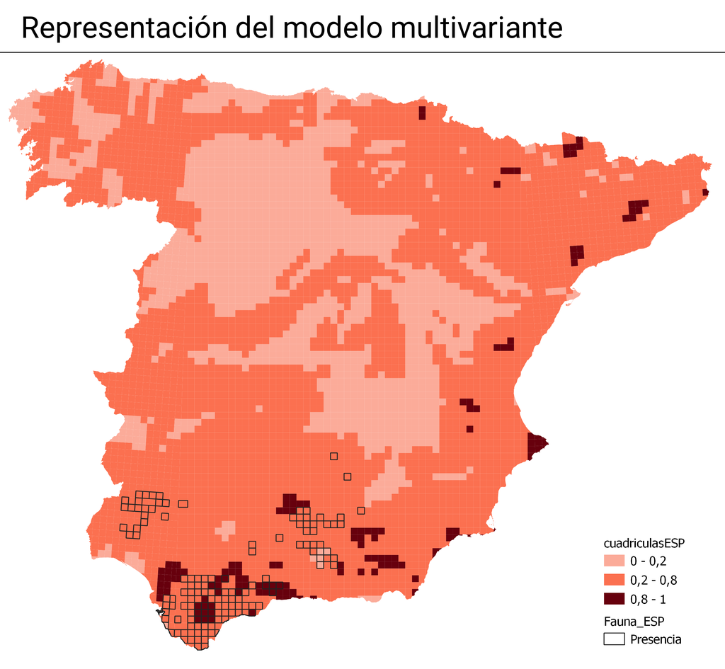

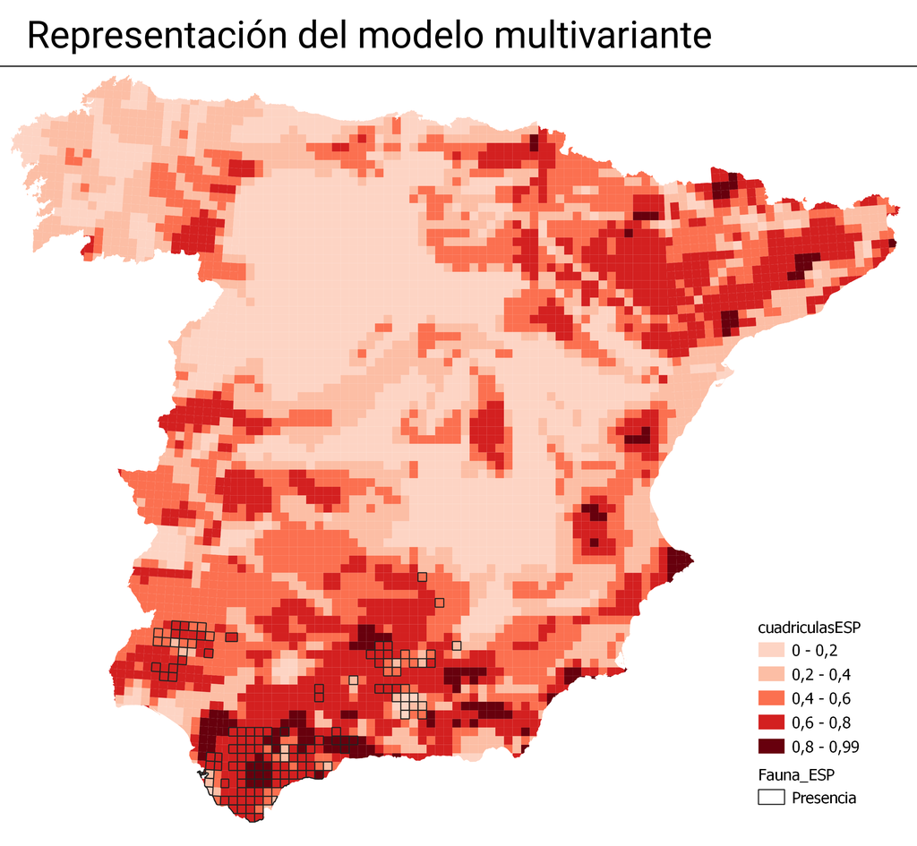

### multGLM

```r
names(datos)
```

```
##  [1] "fid"       "CuadrID"   "latitude"  "longitude" "Area_hec"  "HIE_FAS"
##  [7] "SAL_SAL"   "ALY_DIC"   "DIS_JEA"   "VIP_LAT"   "CAP_PYR"   "CAN_LUP"
## [13] "URS_ARC"   "MUS_LUT"   "GAL_PYR"   "ATE_ALG"   "MAC_CAL"   "PAR_APO"
## [19] "LUC_CER"   "APT_APT"   "LOP"       "LOP2"      "LOP3"      "LALOP2"
## [25] "LA2LOP"    "LALOP"     "LA2"       "LA3"       "LA"        "ORS"
## [31] "ORW"       "ALTI"      "ALTI2"     "PEND"      "PEND2"     "DAUT"
## [37] "DIHE"      "DIPR"      "ESCO"      "ETP"       "ETR"       "HUEN"
## [43] "HUJU"      "INSO"      "PERM"      "PM24"      "PMR"       "PREC"
## [49] "RADS"      "TENE"      "TJUL"      "TMED"      "U100"      "U500"
```

```r
multGLM.MAC_CAL0 <- multGLM(data = datos, which(colnames(datos)=="MAC_CAL"), var.cols = 21:54, id.col=1, step=TRUE, Fav = TRUE)
```

```
## All 5156 observations used for model training;
##               none reserved for model testing.
```

```
##
##
## => Building model 1 of 1 (MAC_CAL)...
##
## 34 input predictor variable(s)
```

[output not shown]

[output cut: 1166 more lines]

[output not shown]

```
## 18 variable(s) excluded by 'step' function
##  LOP, LOP2, LOP3, LALOP2, LA2LOP, LALOP, LA2, ORW, PEND2, ESCO, ETR, INSO, PREC, RADS, TENE, TMED, U100, U500
```

```
## 4 variable(s) excluded by 'modelTrim' function
##  LA, ETP, DAUT, PERM
##
## 12 variable(s) INCLUDED IN THE FINAL MODEL
##  LA3, PMR, TJUL, PEND, DIPR, ALTI2, ORS, PM24, DIHE, ALTI, HUEN, HUJU
```

```
## Finished!
```

```
## It took 32.5 secs.
```

```r
save(multGLM.MAC_CAL0, file="multGLM.MAC_CAL0.rda")
```

Considerando FDR:

```r
multGLM.MAC_CAL1 <- multGLM(data = datos, which(colnames(datos)=="MAC_CAL"), var.cols = 21:54, id.col=1, step=TRUE, Fav = TRUE, FDR=TRUE)
```

```
## All 5156 observations used for model training;
##               none reserved for model testing.
```

```
##
##
## => Building model 1 of 1 (MAC_CAL)...
##
## 34 input predictor variable(s)
##
## 5 variable(s) excluded by 'FDR' function
##  ESCO, HUJU, HUEN, PMR, ORS
```

[output not shown]

[output cut: 690 more lines]

[output not shown]

```
## 16 variable(s) excluded by 'step' function
##  LOP, LOP2, LOP3, LALOP2, LA2LOP, LALOP, LA2, ORW, PEND2, ETR, INSO, RADS, TENE, TMED, U100, U500
##
## 0 variable(s) excluded by 'modelTrim' function
##
##
## 13 variable(s) INCLUDED IN THE FINAL MODEL
##  LA, PREC, LA3, DIPR, TJUL, PEND, ALTI2, ETP, DAUT, DIHE, PM24, ALTI, PERM
```

```
## Finished!
```

```
## It took 20.2 secs.
```

```r
save(multGLM.MAC_CAL1, file="multGLM.MAC_CAL1.rda")
```

Considerando corSelect:

```r
multGLM.MAC_CAL2 <- multGLM(data = datos, which(colnames(datos)=="MAC_CAL"), var.cols = 21:54, id.col=1, step=TRUE, Fav = TRUE, FDR=TRUE, corSelect=TRUE)
```

```
## All 5156 observations used for model training;
##               none reserved for model testing.
```

```
##
##
## => Building model 1 of 1 (MAC_CAL)...
##
## 34 input predictor variable(s)
##
## 5 variable(s) excluded by 'FDR' function
##  ESCO, HUJU, HUEN, PMR, ORS
##
## 16 variable(s) excluded by 'corSelect' function
##  LOP LOP2 LOP3 LALOP2 LALOP LA2 LA3 ALTI ALTI2 PEND2 DIHE ETP INSO PREC RADS TMED
```

```
## 6 variable(s) excluded by 'step' function
##  ORW, DAUT, PERM, PM24, U100, U500
##
## 1 variable(s) excluded by 'modelTrim' function
##  LA2LOP
##
## 6 variable(s) INCLUDED IN THE FINAL MODEL
##  LA, ETR, PEND, TJUL, TENE, DIPR
```

```
## Finished!
```

```
## It took 4.2 secs.
```

```r
save(multGLM.MAC_CAL2, file="multGLM.MAC_CAL2.rda")
```

Utilizando trim:

```r
multGLM.MAC_CAL3 <- multGLM(data = datos, which(colnames(datos)=="MAC_CAL"), var.cols = 21:54, id.col=1, step=TRUE, Fav = TRUE, FDR=TRUE, corSelect=TRUE, trim = TRUE)
```

```
## All 5156 observations used for model training;
##               none reserved for model testing.
```

```
##
##
## => Building model 1 of 1 (MAC_CAL)...
##
## 34 input predictor variable(s)
##
## 5 variable(s) excluded by 'FDR' function
##  ESCO, HUJU, HUEN, PMR, ORS
##
## 16 variable(s) excluded by 'corSelect' function
##  LOP LOP2 LOP3 LALOP2 LALOP LA2 LA3 ALTI ALTI2 PEND2 DIHE ETP INSO PREC RADS TMED
```

```
## 6 variable(s) excluded by 'step' function
##  ORW, DAUT, PERM, PM24, U100, U500
##
## 1 variable(s) excluded by 'modelTrim' function
##  LA2LOP
##
## 6 variable(s) INCLUDED IN THE FINAL MODEL
##  LA, ETR, PEND, TJUL, TENE, DIPR
```

```
## Finished!
```

```
## It took 4.2 secs.
```

```r
save(multGLM.MAC_CAL3, file="multGLM.MAC_CAL3.rda")
```

Summary de todos los modelos:

```r
summary(multGLM.MAC_CAL0$models$MAC_CAL)
```

```
##
## Call:
## glm(formula = MAC_CAL ~ LA3 + PMR + TJUL + PEND + DIPR + ALTI2 +
##     ORS + PM24 + DIHE + ALTI + HUEN + HUJU, family = binomial,
##     data = dat)
##
## Deviance Residuals:
##     Min       1Q   Median       3Q      Max
## -2.9878  -0.0162  -0.0003   0.0000   3.8370
##
## Coefficients:
##               Estimate Std. Error z value Pr(>|z|)
## (Intercept)  1.793e+01  6.243e+00   2.873 0.004070 **
## LA3         -7.067e-04  8.905e-05  -7.937 2.08e-15 ***
## PMR         -2.178e+01  3.083e+00  -7.066 1.60e-12 ***
## TJUL         3.859e-01  1.494e-01   2.583 0.009781 **
## PEND         1.866e-01  6.992e-02   2.669 0.007600 **
## DIPR         6.213e-02  1.710e-02   3.632 0.000281 ***
## ALTI2       -2.447e-06  8.289e-07  -2.952 0.003161 **
## ORS         -2.451e-02  9.060e-03  -2.706 0.006819 **
## PM24         1.720e-02  5.526e-03   3.113 0.001853 **
## DIHE        -7.354e-02  2.333e-02  -3.153 0.001617 **
## ALTI         5.099e-03  1.731e-03   2.946 0.003219 **
## HUEN         1.847e-01  5.446e-02   3.392 0.000694 ***
## HUJU        -1.326e-01  4.627e-02  -2.866 0.004151 **
## ---
## Signif. codes:  0 '***' 0.001 '**' 0.01 '*' 0.05 '.' 0.1 ' ' 1
##
## (Dispersion parameter for binomial family taken to be 1)
##
##     Null deviance: 1264.38  on 5155  degrees of freedom
## Residual deviance:  442.84  on 5143  degrees of freedom
## AIC: 468.84
##
## Number of Fisher Scoring iterations: 12
```

```r
summary(multGLM.MAC_CAL1$models$MAC_CAL)
```

```
##
## Call:
## glm(formula = MAC_CAL ~ LA + PREC + LA3 + DIPR + TJUL + PEND +
##     ALTI2 + ETP + DAUT + DIHE + PM24 + ALTI + PERM, family = binomial,
##     data = train.data)
##
## Deviance Residuals:
##     Min       1Q   Median       3Q      Max
## -3.0289  -0.0146   0.0000   0.0000   3.8490
##
## Coefficients:
##               Estimate Std. Error z value Pr(>|z|)
## (Intercept) -9.251e+02  3.782e+02  -2.446  0.01443 *
## LA           3.753e+01  1.522e+01   2.467  0.01364 *
## PREC         7.452e-03  1.095e-03   6.806 1.01e-11 ***
## LA3         -9.354e-03  3.619e-03  -2.584  0.00975 **
## DIPR         7.943e-02  1.718e-02   4.624 3.77e-06 ***
## TJUL         4.673e-01  1.778e-01   2.629  0.00856 **
## PEND         1.823e-01  6.859e-02   2.658  0.00787 **
## ALTI2       -2.663e-06  8.167e-07  -3.261  0.00111 **
## ETP         -1.176e-02  3.858e-03  -3.050  0.00229 **
## DAUT        -3.028e-02  1.040e-02  -2.913  0.00358 **
## DIHE        -6.143e-02  2.316e-02  -2.652  0.00799 **
## PM24        -1.020e-02  4.774e-03  -2.136  0.03269 *
## ALTI         5.019e-03  1.631e-03   3.077  0.00209 **
## PERM        -4.999e-01  2.359e-01  -2.119  0.03410 *
## ---
## Signif. codes:  0 '***' 0.001 '**' 0.01 '*' 0.05 '.' 0.1 ' ' 1
##
## (Dispersion parameter for binomial family taken to be 1)
##
##     Null deviance: 1264.4  on 5155  degrees of freedom
## Residual deviance:  455.2  on 5142  degrees of freedom
## AIC: 483.2
##
## Number of Fisher Scoring iterations: 15
```

```r
summary(multGLM.MAC_CAL2$models$MAC_CAL)
```

```
##
## Call:
## glm(formula = MAC_CAL ~ LA + ETR + PEND + TJUL + TENE + DIPR,
##     family = binomial, data = dat)
##
## Deviance Residuals:
##     Min       1Q   Median       3Q      Max
## -2.2456  -0.0287  -0.0012  -0.0001   3.6488
##
## Coefficients:
##              Estimate Std. Error z value Pr(>|z|)
## (Intercept) 89.360183  14.194459   6.295 3.07e-10 ***
## LA          -3.112338   0.420926  -7.394 1.42e-13 ***
## ETR          0.007586   0.001043   7.274 3.50e-13 ***
## PEND         0.193453   0.044498   4.347 1.38e-05 ***
## TJUL         0.795756   0.134699   5.908 3.47e-09 ***
## TENE        -0.367353   0.110296  -3.331 0.000867 ***
## DIPR         0.040216   0.013686   2.938 0.003299 **
## ---
## Signif. codes:  0 '***' 0.001 '**' 0.01 '*' 0.05 '.' 0.1 ' ' 1
##
## (Dispersion parameter for binomial family taken to be 1)
##
##     Null deviance: 1264.4  on 5155  degrees of freedom
## Residual deviance:  506.5  on 5149  degrees of freedom
## AIC: 520.5
##
## Number of Fisher Scoring iterations: 11
```

```r
summary(multGLM.MAC_CAL3$models$MAC_CAL)
```

```
##
## Call:
## glm(formula = MAC_CAL ~ LA + ETR + PEND + TJUL + TENE + DIPR,
##     family = binomial, data = dat)
##
## Deviance Residuals:
##     Min       1Q   Median       3Q      Max
## -2.2456  -0.0287  -0.0012  -0.0001   3.6488
##
## Coefficients:
##              Estimate Std. Error z value Pr(>|z|)
## (Intercept) 89.360183  14.194459   6.295 3.07e-10 ***
## LA          -3.112338   0.420926  -7.394 1.42e-13 ***
## ETR          0.007586   0.001043   7.274 3.50e-13 ***
## PEND         0.193453   0.044498   4.347 1.38e-05 ***
## TJUL         0.795756   0.134699   5.908 3.47e-09 ***
## TENE        -0.367353   0.110296  -3.331 0.000867 ***
## DIPR         0.040216   0.013686   2.938 0.003299 **
## ---
## Signif. codes:  0 '***' 0.001 '**' 0.01 '*' 0.05 '.' 0.1 ' ' 1
##
## (Dispersion parameter for binomial family taken to be 1)
##
##     Null deviance: 1264.4  on 5155  degrees of freedom
## Residual deviance:  506.5  on 5149  degrees of freedom
## AIC: 520.5
##
## Number of Fisher Scoring iterations: 11
```

```r
predic0 <- multGLM.MAC_CAL0$predictions %>%
  rename(P_0= MAC_CAL_P, F_0 =MAC_CAL_F)


predic1 <- multGLM.MAC_CAL1$predictions %>%
  select("MAC_CAL_P", "MAC_CAL_F") %>%
  rename(P_1= MAC_CAL_P, F_1 =MAC_CAL_F)


predic2 <- multGLM.MAC_CAL2$predictions %>%
  select("MAC_CAL_P", "MAC_CAL_F") %>%
  rename(P_2= MAC_CAL_P, F_2 =MAC_CAL_F)

predic3 <- multGLM.MAC_CAL3$predictions %>%
  select("MAC_CAL_P", "MAC_CAL_F") %>%
  rename(P_3= MAC_CAL_P, F_3 =MAC_CAL_F)

predics <- data.frame(predic0, predic1, predic2, predic3)
```

```r
write.dbf(predic0, file="fav_MAC_MAL_0.dbf")
write.dbf(predics, file="fav_MAC_MAL_all.dbf")
```